**Gold als Kapitalanlage**

Wertentwicklung, Steuervorteile, demografischer Ausblick  
und die Rolle der Banken

Stand März 2026 · Datenbasis: Yahoo Finance, ECB, London Bullion Market

# 1 Methodik und Datenbasis

Diese Analyse vergleicht physisches Gold (XAU, Londoner Abendfix) mit dem S&P 500 Total Return Index (USD, inklusive reinvestierter Dividenden) und dem DAX Performance-Index (EUR, inklusive Dividenden) aus Sicht eines deutschen Anlegers. Alle Werte wurden in Euro umgerechnet. Als Startkapital dienen jeweils 1.000 € zu Monatsbeginn jedes Jahres von 2000 bis 2025. Für die Steuerbetrachtung wird die aktuelle deutsche Abgeltungsteuer (26,375 % inkl. Solidaritätszuschlag) sowie die Teilfreistellung von 30 % für Aktien-ETFs (effektiver Steuersatz: 18,46 %) angewendet.

# 2 Wertentwicklung seit 2000

Wer im Jahr 2000 je 1.000 € in Gold, den S&P 500 TR und den DAX investiert hätte, erzielt heute fundamental unterschiedliche Ergebnisse: Gold wuchs auf € 14,115 (10.9 % p.a.), der S&P 500 TR auf € 4,631 netto (6.2 % p.a. netto) und der DAX auf € 2,834 netto (4.2 % p.a. netto). Gold übertrifft beide Aktienindizes über diesen Zeitraum erheblich.

Der Schlüssel zu Golds Outperformance liegt in zwei schweren Aktienmarktkrisen: Erstens der Dotcom-Blase (2000–2002), in der DAX und S&P 500 mehr als 50 % verloren, während Gold nahezu stabil blieb. Zweitens der Finanzkrise 2008/09, in der Aktien erneut rund 50 % einbrachen und Gold als sicherer Hafen gefragt war.

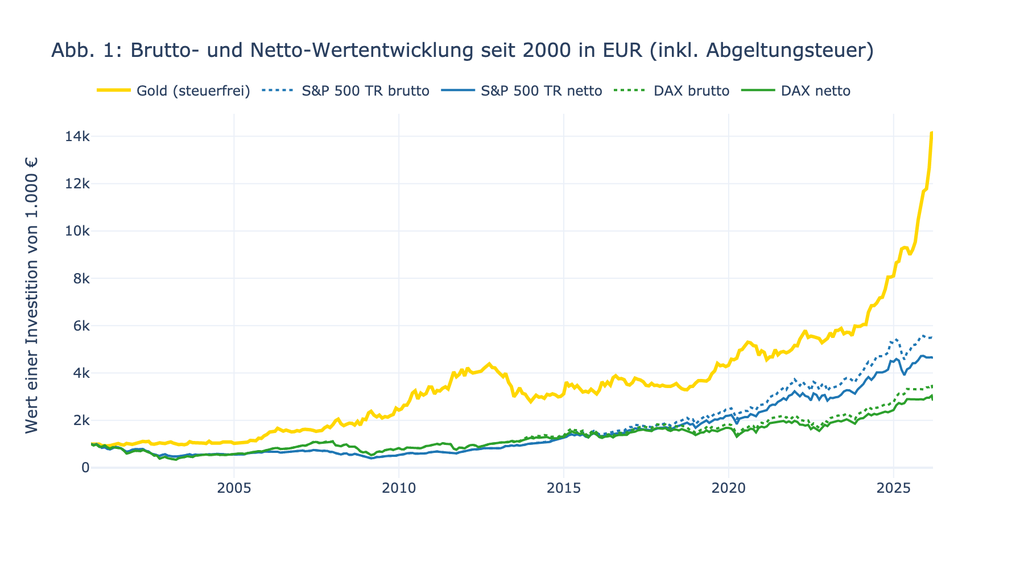

Abb. 1: Brutto- und Netto-Wertentwicklung seit 2000 in EUR (inkl. Abgeltungsteuer)

# 3 Vergleich nach Startjahr (2000–2025)

Je nach Einstiegszeitpunkt verändert sich das Bild deutlich. Gold dominiert in Krisenzeiten und bei langem Zeithorizont; der S&P 500 TR überholt Gold im Zeitraum 2008–2013. Ab 2014 führt Gold wieder in den meisten Jahren. Die folgende Tabelle zeigt die Netto-Ergebnisse für jedes einzelne Startjahr.

| **Start** | **Jahre** | **Gold netto** | **Gold CAGR** | **S&P 500 netto** | **S&P CAGR** | **DAX netto** | **DAX CAGR** | **Goldvorteil*** |
| --- | --- | --- | --- | --- | --- | --- | --- | --- |
| 2000 | 26 | €14,115 | 10.9% | €4,631 | 6.2% | €2,834 | 4.2% | +€9,485 |
| 2001 | 25 | €15,432 | 11.5% | €5,316 | 6.9% | €2,998 | 4.5% | +€10,116 |
| 2002 | 24 | €13,504 | 11.4% | €5,872 | 7.6% | €3,928 | 5.8% | +€7,632 |
| 2003 | 23 | €12,953 | 11.7% | €9,436 | 10.2% | €7,142 | 8.9% | +€3,517 |
| 2004 | 22 | €13,581 | 12.5% | €8,056 | 9.9% | €4,895 | 7.4% | +€5,525 |
| 2005 | 21 | €13,630 | 13.2% | €7,984 | 10.3% | €4,678 | 7.6% | +€5,646 |
| 2006 | 20 | €9,364 | 11.8% | €6,754 | 10.0% | €3,554 | 6.5% | +€2,610 |
| 2007 | 19 | €8,763 | 12.0% | €6,317 | 10.1% | €3,001 | 5.9% | +€2,446 |
| 2008 | 18 | €7,108 | 11.4% | €7,390 | 11.7% | €2,975 | 6.2% | €-282 |
| 2009 | 17 | €6,096 | 11.1% | €10,304 | 14.6% | €4,592 | 9.3% | €-4,208 |
| 2010 | 16 | €5,688 | 11.4% | €8,467 | 14.2% | €3,593 | 8.3% | €-2,779 |
| 2011 | 15 | €4,528 | 10.5% | €6,830 | 13.6% | €2,886 | 7.3% | €-2,302 |
| 2012 | 14 | €3,344 | 8.9% | €6,321 | 14.0% | €3,145 | 8.5% | €-2,977 |
| 2013 | 13 | €3,599 | 10.3% | €5,588 | 14.0% | €2,643 | 7.7% | €-1,989 |
| 2014 | 12 | €4,807 | 13.8% | €4,620 | 13.5% | €2,239 | 6.9% | +€187 |
| 2015 | 11 | €3,900 | 13.0% | €3,433 | 11.7% | €1,972 | 6.3% | +€467 |
| 2016 | 10 | €4,314 | 15.5% | €3,343 | 12.7% | €2,136 | 7.8% | +€971 |
| 2017 | 9 | €3,925 | 16.2% | €2,776 | 11.9% | €1,842 | 6.9% | +€1,149 |
| 2018 | 8 | €4,103 | 19.0% | €2,559 | 12.3% | €1,634 | 6.2% | +€1,544 |
| 2019 | 7 | €3,840 | 20.8% | €2,426 | 13.3% | €1,896 | 9.4% | +€1,413 |
| 2020 | 6 | €3,080 | 20.2% | €1,957 | 11.6% | €1,657 | 8.6% | +€1,123 |
| 2021 | 5 | €2,898 | 23.1% | €1,844 | 12.7% | €1,608 | 9.7% | +€1,053 |
| 2022 | 4 | €2,741 | 27.8% | €1,422 | 8.9% | €1,420 | 8.9% | +€1,319 |
| 2023 | 3 | €2,476 | 33.8% | €1,494 | 13.8% | €1,448 | 12.6% | +€982 |
| 2024 | 2 | €2,333 | 49.3% | €1,269 | 11.9% | €1,316 | 13.9% | +€1,018 |
| 2025 | 1 | €1,630 | 55.2% | €1,007 | 0.7% | €1,064 | 5.8% | +€566 |

* Goldvorteil netto: Differenz zum besten Aktienindex nach Steuer. Netto = nach Abgeltungsteuer (Gold steuerfrei; Aktien-ETF 18,46 % eff.).

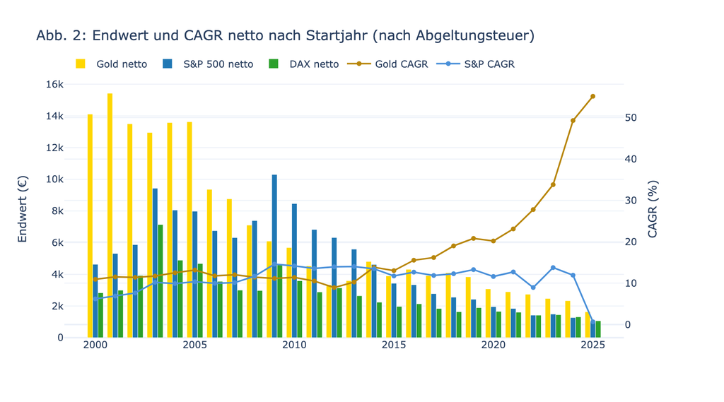

Abb. 2: Endwert und CAGR netto nach Startjahr (nach Abgeltungsteuer)

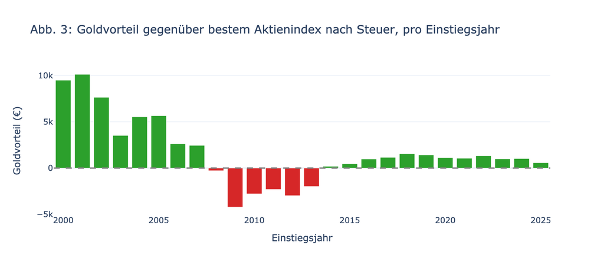

Abb. 3: Goldvorteil gegenüber bestem Aktienindex nach Steuer, pro Einstiegsjahr

# 4 Steuerliche Vorteile von Gold in Deutschland

Die Steuergesetzgebung begünstigt physisches Gold in Deutschland in einzigartiger Weise gegenüber Wertpapieren. Der Unterschied ist erheblich und wird von vielen Anlegern systematisch unterschätzt.

## 4.1 Spekulationsfrist nach § 23 EStG

Physisches Gold (Barren, Münzen) gilt als privates Veräußerungsgeschäft. Gewinne aus dem Verkauf sind nach einer Haltedauer von mehr als einem Jahr vollständig steuerfrei – ohne Betragsbegrenzung. Wer im Jahr 2000 für 1.000 € Gold kaufte und heute verkauft, erzielt einen steuerfreien Gewinn von rund € 13,115. Kein anderes Anlageinstrument bietet diese Kombination aus Renditepotenzial und vollständiger Steuerfreiheit.

## 4.2 Aktien und ETFs: Abgeltungsteuer und Vorabpauschale

Kursgewinne und Dividenden aus Aktien und Aktienfonds unterliegen der Abgeltungsteuer von 25 % zuzüglich 5,5 % Solidaritätszuschlag, insgesamt 26,375 % (ohne Kirchensteuer). Für Aktien-ETFs gilt zwar eine Teilfreistellung von 30 %, die den effektiven Steuersatz auf ca. 18,46 % senkt – dennoch ist jeder thesaurierende Fonds zusätzlich der Vorabpauschale unterworfen, einer jährlichen Mindestbesteuerung auch ohne Verkauf.

## 4.3 Quantitativer Steuereffekt

Der Steuereffekt ist erheblich: Aus 1.000 € in einem S&P 500 Aktien-ETF seit 2000 werden brutto € 5,452, nach Steuer jedoch nur € 4,631. Gold hingegen: brutto wie netto € 14,115.

- Gold (physisch, >1 Jahr): 0 % Steuer auf Kursgewinne
- Aktien-ETF (thesaurierend): 18,46 % eff. Steuer auf Kursgewinne + Vorabpauschale jährlich
- Aktien direkt / aktiv verwaltete Fonds: 26,375 % auf Kursgewinne und Dividenden
- Gold-ETF/ETC: Steuerlich wie Wertpapiere behandelt – kein Steuervorteil!

Wichtig: Nur physisches Gold (Barren, Münzen wie Krügerrand, Maple Leaf, Wiener Philharmoniker) profitiert von der Steuerfreiheit nach §23 EStG. Gold-ETFs, Gold-ETCs (z.B. Xetra-Gold mit physischer Lieferungsoption: steuerfrei; andere ohne Lieferrecht: steuerpflichtig!) und Goldaktien werden steuerlich wie Wertpapiere behandelt.

# 5 Demografischer Gegenwind für Aktien: Die Boomer-Liquidierung

Die geburtenstarken Jahrgänge (Babyboomer, ca. 1946–1964) sind die reichste Anlegergeneration der Geschichte. Sie haben über Jahrzehnte systematisch Kapital in Aktien, Aktienfonds und betriebliche Altersvorsorgepläne eingezahlt – und stehen nun kurz davor, dieses Kapital zu entnehmen.

## 5.1 Das Ausmaß der Kapitalumschichtung

In Deutschland halten Privathaushalte laut Bundesbank Aktien und Investmentfonds im Wert von über 1,5 Billionen Euro. Der Großteil davon entfällt auf die Generation 60+. In den USA verwalten Boomer mit Stand 2023 rund 52 % des gesamten Aktienvermögens. Zwischen 2025 und 2035 erreichen die stärksten Jahrgänge das Alter von 70–80 Jahren.

## 5.2 Strukturelle Konsequenzen für Aktienmärkte

- Netto-Abflüsse aus Aktienfonds: Steigende Netto-Entnahmen aus 401(k)-Plänen seit 2022.
- Required Minimum Distributions (USA): Ab 73 Jahren Zwangsverkäufe aus Altersvorsorge.
- Europa/Deutschland: Riester-, Rürup- und Betriebsrenten zahlen Milliardenbeträge aus.
- Erbschaftswelle: Portfolios werden oft umgeschichtet oder verkauft.

## 5.3 Gold profitiert strukturell

Gold hat keinen Eigentümer der verkaufen muss. Die wichtigsten strukturellen Goldkäufer sind Zentralbanken (Rekordkäufe 2022–2024: über 1.000 Tonnen p.a.), aufstrebende Mittelschichten in Asien (China, Indien) und staatliche Reservefonds. Diese Nachfrage ist demographisch unabhängig und wächst. Gleichzeitig sinkt das Goldangebot: Neue Minen werden seltener erschlossen, die Förderkosten (All-in Sustaining Costs) steigen jährlich.

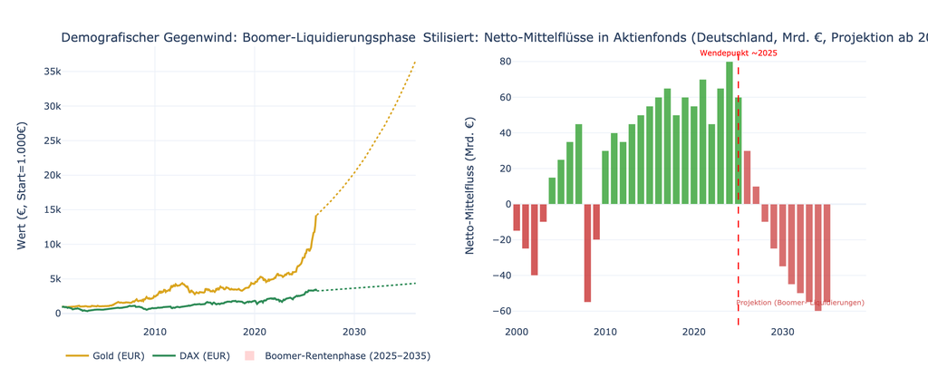

Abb. 5: Demografischer Gegenwind und Netto-Mittelflüsse in Aktienfonds

# 6 Fehlberatung durch Banken und Finanzvertriebe

Gold war eine der renditestärksten und steuerlich effizientesten Anlageformen der letzten 25 Jahre. Dennoch empfehlen Banken Gold systematisch wenig oder gar nicht – wegen struktureller Interessenkonflikte.

## 6.1 Das Provisionsmodell

Bankberater werden durch Provisionen vergütet: Ausgabeaufschläge (3–5 %), Bestandsprovisionen (0,5–1,0 % p.a.) und Performance-Fees. Gold hat keine solchen Provisionsstrukturen.

## 6.2 Kostenwirkung über die Zeit

Ein typischer Ausgabeaufschlag von 5 % bedeutet, dass von 1.000 € direkt 50 € verloren gehen. Laufende Kosten (TER) von 1,5–2,5 % pro Jahr vs. 0,1–0,2 % bei ETFs oder 0 % bei physischem Gold.

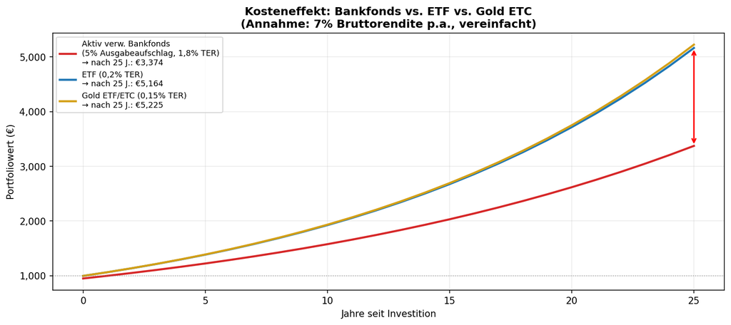

## 6.3 Bekannte Fälle von Fehlberatung

- Lehman-Zertifikate als „sicher" verkauft – mit voller Provision
- Geschlossene Fonds (Schiffsfonds, Immobilienfonds) vor Masseninsolvenzen empfohlen
- Interessenkonflikt: Berater verdienen an Fonds, nicht an Gold oder ETFs
- Komplexität als Instrument: Je komplexer, desto höher die Marge
- Eigenprodukte: Banken bevorzugen eigene Hausfonds mit hohen Kosten

## 6.4 Regulatorische Situation

MiFID II (seit 2018) schreibt mehr Transparenz vor, wird aber oft nur formal eingehalten. Großbritannien hat Provisionen 2012 verboten (RDR). In Deutschland steht ein entsprechendes Verbot noch aus.

# 7 Fazit und Ausblick

Die Datenlage ist eindeutig: Physisches Gold hat europäische Anleger in den letzten 25 Jahren besser gestellt als Aktien – und dies gilt umso mehr nach Steuern.

- Krisenresistenz: Gold verliert in Marktcrashs kaum an Wert, während Aktien 50 %+ einbrachen.
- Steuervorteil: Physisches Gold ist nach einem Jahr vollständig steuerfrei.
- Währungseffekt: Der schwächere US-Dollar stärkte den Goldpreis in EUR-Sicht zusätzlich.

Für die kommenden Jahre kommen strukturelle Rückenwinde hinzu: Die Liquidierungen der Boomer-Generation dürften Aktienindizes belasten, während Zentralbanknachfrage und geopolitische Unsicherheit Gold weiter stützen.

Dennoch ist Gold kein Allheilmittel: Im Zeitraum 2008–2013 zeigte der S&P 500 TR eine deutliche Outperformance. Eine ausgewogene Strategie empfiehlt sich – mit einem Goldanteil als Krisenpuffer und steuereffizientem Wertspeicher, ergänzt durch kostengünstige Aktien-ETFs. Das Wichtigste: aktiv verwaltete Bankfonds mit hohen Kosten meiden.